# OpenIntro Statistics

Rodrigo Martins

March 29, 2015

## CHAPTER 1 - INTRODUCTION TO DATA

### Exercise 1.1

Of the 224 patients in the treatment group, 45 had a stroke by the end of the first year. Using these two numbers, compute the proportion of patients in the treatment group who had a stroke by the end of their first year.

```r
setwd("/Volumes/E-Books and articles/e-Books & articles/R/OpenIntro Statistics/openintroData")
load("stent.rda")
s30 <- as.data.frame(rbind(table((split(stent, stent$period)[[1]])[, 1:2]),
    colSums(table((split(stent, stent$period)[[1]])[, 1:2]))))
rownames(s30) <- c("control", "treatment", "TOTAL")
s365 <- as.data.frame(rbind(table((split(stent, stent$period)[[2]])[, 1:2]),
    colSums(table((split(stent, stent$period)[[2]])[, 1:2]))))
rownames(s365) <- c("control", "treatment", "TOTAL")
library(pander)
pander(s30, "Events - 0 to 30 days period", emphasize.strong.rows = 3)
```

Events - 0 to 30 days period

|  | no event | stroke |
| --- | --- | --- |
| **control** | 214 | 13 |
| **treatment** | 191 | 33 |
| **TOTAL** | **405** | **46** |

```r
pander(s365, "Eventsp - 0 to 365 days period", emphasize.strong.rows = 3)
```

Eventsp - 0 to 365 days period

|  | no event | stroke |
| --- | --- | --- |
| **control** | 199 | 28 |
| **treatment** | 179 | 45 |
| **TOTAL** | **378** | **73** |

*ANSWER :*

- Proportion of patientes who had a stroke in treatment group :

```r
round(45/224,3) ; paste((round(45/224,3)*100),'%',sep="")
```

```
## [1] 0.201
```

```
## [1] "20.1%"
```

- Proportion of patientes who had no stroke in treatment group :

```r
round(179/224,3) ; paste((round(179/224,3)*100),'%',sep="")
```

```
## [1] 0.799
```

```
## [1] "79.9%"
```

- Proportion of patientes who had stroke in control group :

```r
round(28/227,2) ; paste((round(28/227,3)*100),'%',sep="")
```

```
## [1] 0.12
```

```
## [1] "12.3%"
```

- Proportion of patientes who had no stroke in control group :

```r
round(199/227,2) ; paste((round(199/227,3)*100),'%',sep="")
```

```
## [1] 0.88
```

```
## [1] "87.7%"
```

### Exercise 1.2

We consider a publicly available data set that summarizes information about the 3,143 counties in the United States, and we call this the `county` data set. This data set includes information about each county: its name, the state where it resides, its population in 2000 and 2010, per capita federal spending, poverty rate, and five additional characteristics. How might these data be organized in a data matrix?

*ANSWER :*

```r
setwd("/Volumes/E-Books and articles/e-Books & articles/R/OpenIntro Statistics/openintroData")
load("county.rda")
library(pander)
panderOptions("table.split.table", 110)
pander(summary(county), "county summary")
```

county summary (continued below)

| name | state | pop2000 | pop2010 | fed_spend |
| --- | --- | --- | --- | --- |
| Washington County: 30 | Texas : 254 | Min. : 67 | Min. : 82 | Min. : 0.000 |
| Jefferson County : 25 | Georgia : 159 | 1st Qu.: 11210 | 1st Qu.: 11104 | 1st Qu.: 6.964 |
| Franklin County : 24 | Virginia: 134 | Median : 24608 | Median : 25857 | Median : 8.669 |
| Jackson County : 23 | Kentucky: 120 | Mean : 89623 | Mean : 98233 | Mean : 9.991 |
| Lincoln County : 23 | Missouri: 115 | 3rd Qu.: 61766 | 3rd Qu.: 66699 | 3rd Qu.: 10.857 |
| Madison County : 19 | Kansas : 105 | Max. :9519338 | Max. :9818605 | Max. :204.616 |
| (Other) :2999 | (Other) :2256 | NA’s :3 | NA | NA’s :4 |

| poverty | homeownership | multiunit | income | med_income | smoking_ban |
| --- | --- | --- | --- | --- | --- |
| Min. : 0.0 | Min. : 0.00 | Min. : 0.00 | Min. : 7772 | Min. : 19351 | comprehensive: 524 |
| 1st Qu.:11.0 | 1st Qu.:69.50 | 1st Qu.: 6.10 | 1st Qu.:19030 | 1st Qu.: 36952 | none :1911 |
| Median :14.7 | Median :74.60 | Median : 9.70 | Median :21773 | Median : 42445 | partial : 681 |
| Mean :15.5 | Mean :73.26 | Mean :12.33 | Mean :22505 | Mean : 44270 | NA’s : 27 |
| 3rd Qu.:19.0 | 3rd Qu.:78.40 | 3rd Qu.:15.90 | 3rd Qu.:24814 | 3rd Qu.: 49142 | NA |
| Max. :53.5 | Max. :91.30 | Max. :98.50 | Max. :64381 | Max. :115574 | NA |
| NA | NA | NA | NA | NA | NA |

```r
panderOptions("table.split.table", 100)
panderOptions("round", 4)
panderOptions("keep.trailing.zeros", TRUE)
pander(head(cbind(entry = 1:nrow(county), county), 5), "How to organize it in a data matrix")
```

How to organize it in a data matrix (continued below)

| entry | name | state | pop2000 | pop2010 | fed_spend | poverty |
| --- | --- | --- | --- | --- | --- | --- |
| 1 | Autauga County | Alabama | 43671 | 54571 | 6.068 | 10.6 |
| 2 | Baldwin County | Alabama | 140415 | 182265 | 6.140 | 12.2 |
| 3 | Barbour County | Alabama | 29038 | 27457 | 8.752 | 25.0 |
| 4 | Bibb County | Alabama | 20826 | 22915 | 7.122 | 12.6 |
| 5 | Blount County | Alabama | 51024 | 57322 | 5.131 | 13.4 |

| homeownership | multiunit | income | med_income | smoking_ban |
| --- | --- | --- | --- | --- |
| 77.5 | 7.2 | 24568 | 53255 | none |
| 76.7 | 22.6 | 26469 | 50147 | none |
| 68.0 | 11.1 | 15875 | 33219 | none |
| 82.9 | 6.6 | 19918 | 41770 | none |
| 82.0 | 3.7 | 21070 | 45549 | none |

- Types of variables in `county`

```r
str(county)
```

```
## 'data.frame':    3143 obs. of  11 variables:
##  $ name         : Factor w/ 1877 levels "Abbeville County",..: 83 90 101 151 166 227 237 250 298 320 ...
##  $ state        : Factor w/ 51 levels "Alabama","Alaska",..: 1 1 1 1 1 1 1 1 1 1 ...
##  $ pop2000      : int  43671 140415 29038 20826 51024 11714 21399 112249 36583 23988 ...
##  $ pop2010      : int  54571 182265 27457 22915 57322 10914 20947 118572 34215 25989 ...
##  $ fed_spend    : num  6.07 6.14 8.75 7.12 5.13 ...
##  $ poverty      : num  10.6 12.2 25 12.6 13.4 25.3 25 19.5 20.3 17.6 ...
##  $ homeownership: num  77.5 76.7 68 82.9 82 76.9 69 70.7 71.4 77.5 ...
##  $ multiunit    : num  7.2 22.6 11.1 6.6 3.7 9.9 13.7 14.3 8.7 4.3 ...
##  $ income       : num  24568 26469 15875 19918 21070 ...
##  $ med_income   : num  53255 50147 33219 41770 45549 ...
##  $ smoking_ban  : Factor w/ 3 levels "comprehensive",..: 2 2 2 2 2 2 2 3 2 1 ...
```

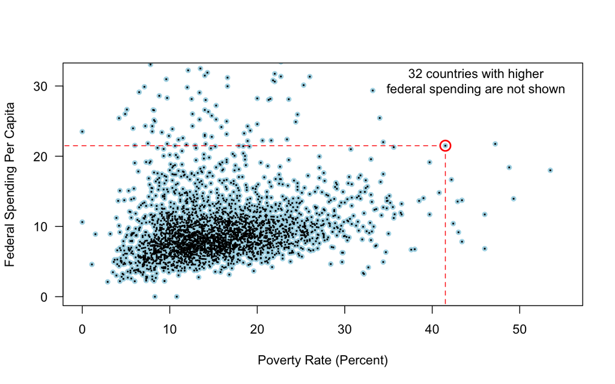

```r
plot(fed_spend ~ poverty, county, xlim = c(0, 55), ylim = c(0, 32), xlab = "Poverty Rate (Percent)",
    ylab = "Federal Spending Per Capita", las = 1, yaxt = "n", pch = 19, col = "lightblue",
    cex = 0.8)
axis(2, at = c(0, 10, 20, 30), las = 2)
text(45, 33, "32 countries with higher\nfederal spending are not shown", pos = 1)
points(fed_spend ~ poverty, county, type = "p", pch = 15, cex = 0.3)
points(fed_spend[county$name == "Owsley County"] ~ poverty[county$name == "Owsley County"],
    county, type = "p", pch = 1, cex = 1.8, col = "red", lwd = 2)
segments(x0 = county$poverty[county$name == "Owsley County"], y0 = -1, x1 = county$poverty[county$name ==
    "Owsley County"], y1 = county$fed_spend[county$name == "Owsley County"] -
    0.8, lty = 2, col = "red")
segments(x0 = -2, y0 = county$fed_spend[county$name == "Owsley County"], x1 = county$poverty[county$name ==
    "Owsley County"] - 0.8, y1 = county$fed_spend[county$name == "Owsley County"],
    lty = 2, col = "red")
```

### Exercise 1.3

Data were collected about students in a statistics course. Three variables were recorded for each student: number of siblings, student height, and whether the student had previously taken a statistics course. Classify each of the variables as continuous numerical, discrete numerical, or categorical.

*ANSWER :*

- **Number of siblings =** mumerical, discrete.
- **Student height =** numerical, continuous.
- **Statistics course (Y/N) =** categorical.

### Exercise 1.4

Consider the variables group and outcome (at 30 days) from the stent study in Section 1.1. Are these numerical or categorical variables?

*ANSWER :* Categorical.

```r
setwd("/Volumes/E-Books and articles/e-Books & articles/R/OpenIntro Statistics/openintroData")
load("stent.rda")
s30 <- as.data.frame(rbind(table((split(stent, stent$period)[[1]])[, 1:2]),
    colSums(table((split(stent, stent$period)[[1]])[, 1:2]))))
rownames(s30) <- c("control", "treatment", "TOTAL")
library(pander)
pander(s30, "Events - 0 to 30 days period", emphasize.strong.rows = 3)
```

Events - 0 to 30 days period

|  | no event | stroke |
| --- | --- | --- |
| **control** | 214 | 13 |
| **treatment** | 191 | 33 |
| **TOTAL** | **405** | **46** |

```r
pander(head(cbind(entry = 1:nrow(stent), stent[, 1:2]), 5), "Head of stent data")
```

Head of stent data

| entry | group | outcome |
| --- | --- | --- |
| 1 | treatment | stroke |
| 2 | treatment | stroke |
| 3 | treatment | stroke |
| 4 | treatment | stroke |
| 5 | treatment | stroke |

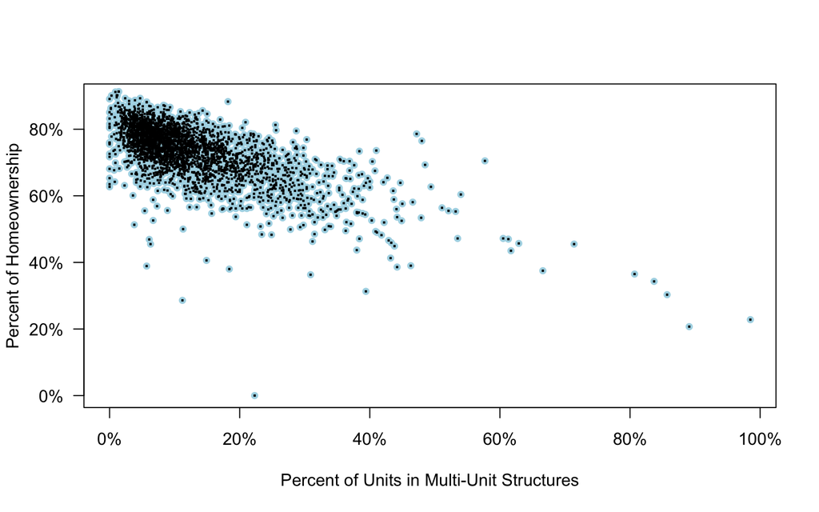

```r
plot(homeownership ~ multiunit, county, ylim = c(0, 90), xlab = "Percent of Units in Multi-Unit Structures",
    ylab = "Percent of Homeownership", las = 1, xaxt = "n", yaxt = "n", pch = 19,
    col = "lightblue", cex = 0.8)
axis(1, at = c(0, 20, 40, 60, 80, 100), lab = paste0(seq(0, 100, by = 20), "%"),
    las = 1)
axis(2, at = c(0, 20, 40, 60, 80), lab = paste0(seq(0, 80, by = 20), "%"), las = 2)
points(homeownership ~ multiunit, county, type = "p", pch = 15, cex = 0.3)
```

### Exercise 1.5

Examine the variables in the `email50` data set, which are described in Table 1.4 on page 4. Create two questions about the relationships between these variables that are of interest to you.

- Is the number of destinataries (*to_multiple*) related to *spam* messages ?
- Is the number of dollar signs (*dollar*) related to *spam* messages ?

```r
setwd("/Volumes/E-Books and articles/e-Books & articles/R/OpenIntro Statistics/openintroData")
load('email50.rda')
library(pander)
panderOptions("table.split.table", 120)
panderOptions('keep.trailing.zeros', TRUE)
pander(head(email50,5),"Head - email50 data set")
```

Head - email50 data set (continued below)

| spam | to_multiple | from | cc | sent_email | time | image | attach | dollar |
| --- | --- | --- | --- | --- | --- | --- | --- | --- |
| 0 | 0 | 1 | 0 | 1 | 2012-01-04 05:19:16 | 0 | 0 | 0 |
| 0 | 0 | 1 | 0 | 0 | 2012-02-16 12:10:06 | 0 | 0 | 0 |
| 1 | 0 | 1 | 4 | 0 | 2012-01-04 07:36:23 | 0 | 2 | 0 |
| 0 | 0 | 1 | 0 | 0 | 2012-01-04 09:49:52 | 0 | 0 | 0 |
| 0 | 0 | 1 | 0 | 0 | 2012-01-27 01:34:45 | 0 | 0 | 9 |

Table continues below

| winner | inherit | viagra | password | num_char | line_breaks | format | re_subj |
| --- | --- | --- | --- | --- | --- | --- | --- |
| no | 0 | 0 | 0 | 21705 | 551 | 1 | 1 |
| no | 0 | 0 | 0 | 7011 | 183 | 1 | 0 |
| no | 0 | 0 | 0 | 631 | 28 | 0 | 0 |
| no | 0 | 0 | 0 | 2454 | 61 | 0 | 0 |
| no | 0 | 0 | 1 | 41623 | 1088 | 1 | 0 |

| exclaim_subj | urgent_subj | exclaim_mess | number |
| --- | --- | --- | --- |
| 0 | 0 | 8 | small |
| 0 | 0 | 1 | big |
| 0 | 0 | 2 | none |
| 0 | 0 | 1 | small |
| 0 | 0 | 43 | small |

### Exercise 1.6

This example examines the relationship between homeownership and the percent of units in multi-unit structures (e.g. apartments, condos), which is visualized using a scatterplot in figure above. Are these variables associated?

- The data suggests that there is a correlation between both variables : it seems that the lower the percentage of multi-unit structures, the higher the percentage of ownership. If there is relationship, they are associated.

### Exercise 1.7

For the second and third questions above, identify the target population and what represents an individual case.

- Over the last 5 years, what is the average time to complete a degree for Duke undergraduate students?
  - *Population :* All the undergraduate students from Duke University who had graduated, in the past 5 years.
  - *Cases :* Each undergraduate student from Duke University, in the past 5 years.
- Does a new drug reduce the number of deaths in patients with severe heart disease?
  - *Population :* All patients with severe heart disease.
  - *Cases :* Each patient with severe heart disease.

### Exercise 1.8

Suppose we ask a student who happens to be majoring in nutrition to select several graduates for the study. What kind of students do you think she might collect? Do you think her sample would be representative of all graduates?

- She will probably collect her colleagues from the same course ou other health-related fields. The sample could not be representative of the population (or could be …). The sample may be **biased**.

### Exercise 1.9

We can easily access ratings for products, sellers, and companies through websites. These ratings are based only on those people who go out of their way to provide a rating. If 50% of online reviews for a product are negative, do you think this means that 50% of buyers are dissatisfied with the product?

- It may indicates that the product is not very well accepted, but probably the fraction of dissatisfied people is different from 50%. This is typical case of convenience sample. AS dissatisfied people usually tend to be very critical, the evaluation may include a negative bias.

### Exercise 1.10

Suppose an observational study tracked sunscreen use and skin cancer, and it was found that the more sunscreen someone used, the more likely the person was to have skin cancer. Does this mean sunscreen causes skin cancer?

- Not necessarily. It shows that the use of sunscreen and having skin cancer is associated, though. The is a **confounding variable**, sun exposure, that is not described in the situation above. A **confounding varible** is correlated to both explanatory and response variables.

### Exercise 1.11

The graph above shows a negative association between the homeownership rate and the percentage of multi-unit structures in a county. However, it is unreasonable to conclude that there is a causal relationship between the two variables. Suggest one or more other variables that might explain the relationship visible in the graph.

- Population density may be important. If a county is very dense, then this may require a larger fraction of residents to live in multi-unit structures. Additionally, the high density may contribute to increases in property value, making homeownership infeasible for many residents.

### Exercise 1.12

Why would it be good for cases within each stratum to be very similar?

- We might get a more stable estimate for the subpopulation in a stratum if the cases are very similar. These improved estimates for each subpopulation will help us build a reliable estimate for the full population.

### Exercise 1.13

Suppose we are interested in estimating the malaria rate in a densely tropical portion of rural Indonesia. We learn that there are 30 villages in that part of the Indonesian jungle, each more or less similar to the next. Our goal is to test 150 individuals for malaria. What sampling method should be employed?

- A simple random sample would likely draw individuals from all 30 villages, which could make data collection extremely expensive. Stratifed sampling would be a challenge since it is unclear how we would build strata of similar individuals. However, cluster sampling seems like a very good idea. First, we might randomly select half the villages, then randomly select 10 people from each. This would probably reduce our data collection costs substantially in comparison to a simple random sample and would still give us reliable information.

### Exercise 1.14

Look back to the study in Section 1.1 where researchers were testing whether stents were effective at reducing strokes in at-risk patients. Is this an experiment? Was the study blinded? Was it double-blinded?

- *Experiment ? :* Yes, because the researches controled the design of the test.
- *Blinded ? :* No, because the patients know if they received of not the stent.
- *Double-blinded ? :* No, because it would be easy to reasearchers and doctors to know if a patient received or not the stent. A expiriment which is not blind, cannot be double-blind.

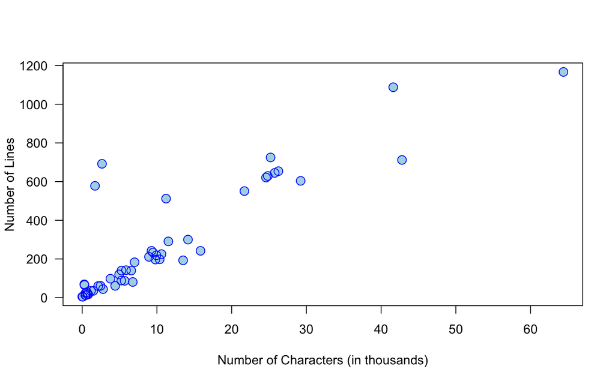

```r
setwd("/Volumes/E-Books and articles/e-Books & articles/R/OpenIntro Statistics/openintroData")
load("email50.rda")
nc1000 <- (email50$num_char/1000)
plot(email50$line_breaks ~ nc1000, xlab = "Number of Characters (in thousands)",
    ylab = "Number of Lines", las = 1, pch = 19, col = "lightblue", cex = 1.5)
points(email50$line_breaks ~ nc1000, type = "p", pch = 1, cex = 1.5, col = "blue",
    lwd = 1)
```

### Exercise 1.15

What do scatterplots reveal about the data, and how might they be useful?

- Scaterplots may reveal relations and trends between variables.

### Exercise 1.16

Consider a new data set of 54 cars with two variables: vehicle price and weight. A scatterplot of vehicle price versus weight is shown below. What can be said about the relationship between these variables?

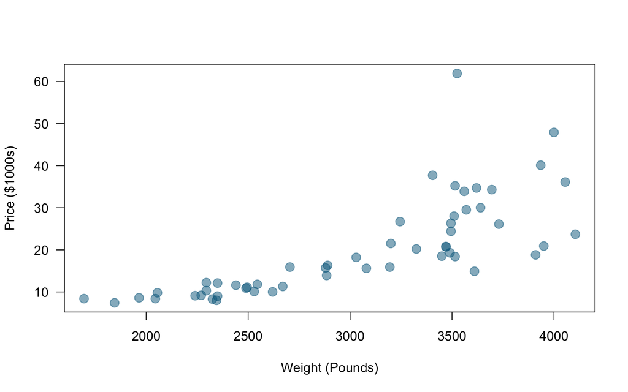

```r
setwd("/Volumes/E-Books and articles/e-Books & articles/R/OpenIntro Statistics/openintroData")
if ("scales" %in% rownames(installed.packages()) == FALSE) {
    install.packages("scales")
}
library(scales)
load("cars.rda")
plot(price.1000 ~ weight.lb, cars, xlab = "Weight (Pounds)", ylab = "Price ($1000s)",
    las = 1, pch = 19, col = alpha("deepskyblue4", 0.5), cex = 1.5)
```

- The scatterplot indicates a positive correlation between weight and price. The higher is the weight, the higher is the price. The relationship does not seems linear.

### Exercise 1.17

Describe two variables that would have a horseshoe shaped association in a scatterplot.

- Variables with quadractic correlation may show the mentioned shape.
- Consider the case where your vertical axis represents something “good” and your horizontal axis represents something that is only good in moderation. Health and water consumption fit this description since water becomes toxic when consumed in excessive quantities.